# credit_worthiness_prediction

```python
import numpy as np
import pandas as pd
import matplotlib.pyplot as plt
import seaborn as sns
from sklearn.preprocessing import LabelEncoder, StandardScaler
from sklearn.model_selection import train_test_split
from sklearn.ensemble import RandomForestClassifier
import lightgbm as lgb
import statsmodels.api as sm
from sklearn.metrics import classification_report, auc, roc_curve, f1_score, confusion_matrix
from scipy.stats import entropy
import warnings
warnings.filterwarnings('ignore')
```

The original dataset, though small, is quite complicated because it does not have any headers and the values in categorical columns are symbols that have a mapping in a different document. Due to lack of time, I have cheated a bit and used a version of this dataset that is ready to use. This has been picked up from here (http://datahacking.tech/en/csv-german-credit-data-statlog/). The author of the blog has not messed with the structure of the dataset, he has merely mapped the symbols in the categorical features back to the values they represent, added in the header and rendered the dataset in a csv format instead of the native .data format. The R file (https://github.com/adriangasinski/datahacking_0001/blob/master/00_german_credit.R) has a one line description for every attribute

```python
df_credit = pd.read_csv('german_credit.csv')
df_credit.rename(columns={'default':'credit_worthy'}, inplace=True)
df_credit['credit_worthy'] = 1 - df_credit['credit_worthy']
```

```python
df_credit.head()
```

|  | credit_worthy | account_check_status | duration_in_month | credit_history | purpose | credit_amount | savings | present_emp_since | installment_as_income_perc | personal_status_sex | ... | present_res_since | property | age | other_installment_plans | housing | credits_this_bank | job | people_under_maintenance | telephone | foreign_worker |
| --- | --- | --- | --- | --- | --- | --- | --- | --- | --- | --- | --- | --- | --- | --- | --- | --- | --- | --- | --- | --- | --- |
| 0 | 1 | < 0 DM | 6 | critical account/ other credits existing (not ... | domestic appliances | 1169 | unknown/ no savings account | .. >= 7 years | 4 | male : single | ... | 4 | real estate | 67 | none | own | 2 | skilled employee / official | 1 | yes, registered under the customers name | yes |
| 1 | 0 | 0 <= ... < 200 DM | 48 | existing credits paid back duly till now | domestic appliances | 5951 | ... < 100 DM | 1 <= ... < 4 years | 2 | female : divorced/separated/married | ... | 2 | real estate | 22 | none | own | 1 | skilled employee / official | 1 | none | yes |
| 2 | 1 | no checking account | 12 | critical account/ other credits existing (not ... | (vacation - does not exist?) | 2096 | ... < 100 DM | 4 <= ... < 7 years | 2 | male : single | ... | 3 | real estate | 49 | none | own | 1 | unskilled - resident | 2 | none | yes |
| 3 | 1 | < 0 DM | 42 | existing credits paid back duly till now | radio/television | 7882 | ... < 100 DM | 4 <= ... < 7 years | 2 | male : single | ... | 4 | if not A121 : building society savings agreeme... | 45 | none | for free | 1 | skilled employee / official | 2 | none | yes |
| 4 | 0 | < 0 DM | 24 | delay in paying off in the past | car (new) | 4870 | ... < 100 DM | 1 <= ... < 4 years | 3 | male : single | ... | 4 | unknown / no property | 53 | none | for free | 2 | skilled employee / official | 2 | none | yes |

5 rows × 21 columns

## EDA

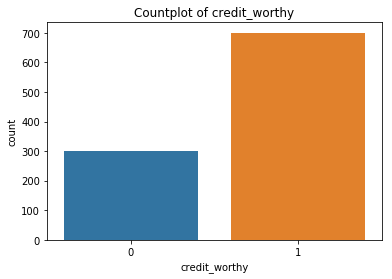

```python
plt.title('Countplot of credit_worthy')
sns.countplot(df_credit['credit_worthy'])
```

The positive and negative classes aren't balanced but they aren't imbalanced to the extent where one may need to think about class imbalance techniques.

#### Would a person with critical credit history, be more credit worthy?

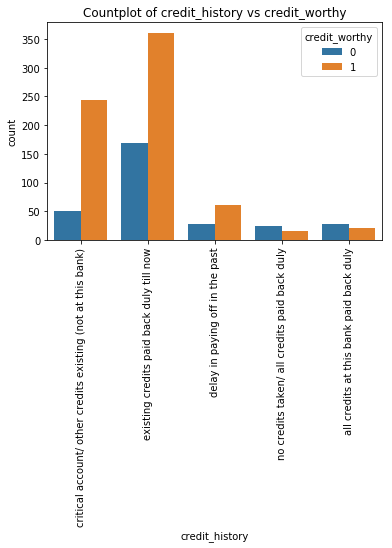

```python
plt.title('Countplot of credit_history vs credit_worthy')
sns.countplot(df_credit['credit_history'], hue=df_credit['credit_worthy'])
plt.xticks(rotation=90)
```

Surprisingly people with a critical credit history are actually the most credit worthy customers. The numerical summary below where we have calculated the proportion of credit_worthy customers confirms the same

```python
display(df_credit.groupby('credit_history').agg(credit_worthy_mean=('credit_worthy','mean'),
                                            count=('credit_history','count')).sort_values('credit_worthy_mean'))
```

| credit_history | credit_worthy_mean | count |
| --- | --- | --- |
| no credits taken/ all credits paid back duly | 0.375000 | 40 |
| all credits at this bank paid back duly | 0.428571 | 49 |
| existing credits paid back duly till now | 0.681132 | 530 |
| delay in paying off in the past | 0.681818 | 88 |
| critical account/ other credits existing (not at this bank) | 0.829352 | 293 |

#### Are young people more credit worthy?

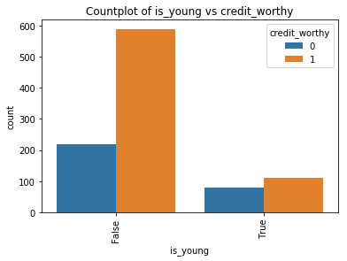

```python
plt.title('Countplot of is_young vs credit_worthy')
df_credit['is_young'] = df_credit['age'] <= 25
sns.countplot(df_credit['is_young'], hue=df_credit['credit_worthy'])
plt.xticks(rotation=90)
```

Anyone who has an age of less than 25 has been considered young. We can see that the likelihood of defaulting for a customer who is young is closer to 0.5 than 1. Thus young customers are not actually credit worthy

```python
display(df_credit.groupby('is_young').agg(credit_worthy_mean=('credit_worthy','mean'),
                                     count=('is_young','count')).sort_values('credit_worthy_mean'))
df_credit.drop('is_young', axis=1, inplace=True)
```

| is_young | credit_worthy_mean | count |
| --- | --- | --- |
| True | 0.578947 | 190 |
| False | 0.728395 | 810 |

#### Would a person with more credit accounts, be more credit worthy?

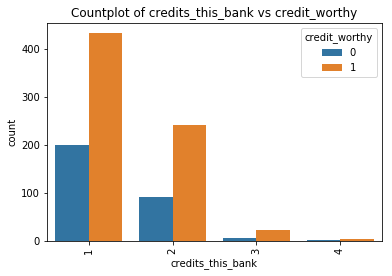

```python
plt.title('Countplot of credits_this_bank vs credit_worthy')
sns.countplot(df_credit['credits_this_bank'], hue=df_credit['credit_worthy'])
plt.xticks(rotation=90)
```

It seems as though the proportion of customers who are more credit_worthy increase with the number of credit accounts at the bank. There are very few customers who have 3-4 credit accounts so one must proceed with caution. The jump from 1 credit account to 2 credit accounts seems significant enough

```python
display(df_credit.groupby('credits_this_bank').agg(credit_worthy_mean=('credit_worthy','mean'),
                                                   count=('credits_this_bank','count')).sort_values('credit_worthy_mean'))
```

| credits_this_bank | credit_worthy_mean | count |
| --- | --- | --- |
| 4 | 0.666667 | 6 |
| 1 | 0.684044 | 633 |
| 2 | 0.723724 | 333 |
| 3 | 0.785714 | 28 |

## Preprocessing

Since we have a lot of categorical variables, we need to preprocess them so that they can be used by the prediction algorithms. The kind of preprocessing depends on the algorithm we use. Tree based models that work well with categorical data generally don't require us to one-hot encode (dummify) the categorical attributes, thus we can just label encode them. Linear models on the other hand are meaningless if categorical attributes with more than one level are included in the training data without one-hot encoding them. They also require continuous attributes to be on the same scale

```python
# Preprocessing
categ_cols = list((df_credit.dtypes[df_credit.dtypes == 'object']).index) # Categorical columns
rem_cols = list(set(df_credit.columns) - set(categ_cols))
cont_cols = list(set(rem_cols) - set(['credit_worthy'])) # Continuous columns
dict_le = {} # Saving the label encoder for every attribute. This will be used for inverse transformations
df_preprocessed = pd.DataFrame()
for col in categ_cols:
    le = LabelEncoder()
    le.fit(df_credit[col])
    dict_le[col] = le
    df_preprocessed[col] = le.transform(df_credit[col])
df_preprocessed = pd.concat([df_preprocessed, df_credit[rem_cols]], axis=1)

df_preprocessed.head()
```

|  | account_check_status | credit_history | purpose | savings | present_emp_since | personal_status_sex | other_debtors | property | other_installment_plans | housing | ... | telephone | foreign_worker | present_res_since | credits_this_bank | credit_worthy | people_under_maintenance | duration_in_month | age | installment_as_income_perc | credit_amount |
| --- | --- | --- | --- | --- | --- | --- | --- | --- | --- | --- | --- | --- | --- | --- | --- | --- | --- | --- | --- | --- | --- |
| 0 | 1 | 1 | 4 | 4 | 0 | 3 | 2 | 2 | 1 | 1 | ... | 1 | 1 | 4 | 2 | 1 | 1 | 6 | 67 | 4 | 1169 |
| 1 | 0 | 3 | 4 | 1 | 2 | 0 | 2 | 2 | 1 | 1 | ... | 0 | 1 | 2 | 1 | 0 | 1 | 48 | 22 | 2 | 5951 |
| 2 | 3 | 1 | 0 | 1 | 3 | 3 | 2 | 2 | 1 | 1 | ... | 0 | 1 | 3 | 1 | 1 | 2 | 12 | 49 | 2 | 2096 |
| 3 | 1 | 3 | 7 | 1 | 3 | 3 | 1 | 0 | 1 | 0 | ... | 0 | 1 | 4 | 1 | 1 | 2 | 42 | 45 | 2 | 7882 |
| 4 | 1 | 2 | 2 | 1 | 2 | 3 | 2 | 3 | 1 | 0 | ... | 0 | 1 | 4 | 2 | 0 | 2 | 24 | 53 | 3 | 4870 |

5 rows × 21 columns

The data set will be split into train, validation and test set.

- We will train our model on the train set
- Hyperparameters will be tuned on the validation set
- The test set will be used for evaluating the generalizability of the models we train

The right way to validate the thresholds would be to use Leave One Out Cross Validation (LOOCV) since we don't have enough data. Even a K-Fold CV would probably work well.

```python
# 15% split for train and test set. The train set is further split into train and validation sets
X_train, X_test, y_train, y_test = train_test_split(df_preprocessed.drop('credit_worthy', axis=1),
                                                    df_preprocessed['credit_worthy'],
                                                    test_size=0.15,
                                                    random_state=42)
X_train, X_val, y_train, y_val = train_test_split(X_train,
                                                  y_train,
                                                  test_size=0.18, # To have an equal number of observations in test & val
                                                  random_state=42)
```

```python
# Check to see if the same set of unique values exist in categorical columns of train, val and test set
for col in categ_cols:
    try:
        assert(set(X_train[col].unique()) == set(X_val[col].unique()) == set(X_test[col].unique()))
        print('Check passed for', col)
    except:
        print('\nCheck failed for', col,'\n')
```

```
Check passed for account_check_status
Check passed for credit_history

Check failed for purpose

Check passed for savings
Check passed for present_emp_since
Check passed for personal_status_sex
Check passed for other_debtors
Check passed for property
Check passed for other_installment_plans
Check passed for housing
Check passed for job
Check passed for telephone
Check passed for foreign_worker
```

```python
X_train[categ_cols].nunique()
```

```
account_check_status        4
credit_history              5
purpose                    10
savings                     5
present_emp_since           5
personal_status_sex         4
other_debtors               3
property                    4
other_installment_plans     3
housing                     3
job                         4
telephone                   2
foreign_worker              2
dtype: int64
```

The categorical attributes don't have a high cardinality. One-hot encoding all of them and including them in the training data for our linear models shouldn't be an issue

## Model Building

The 3 models that we'll build are:

- Random Forest: Tree based
- LightGBM (Gradient Boosting): Tree based
- Logistic Regression: Linear

The 3 models are diverse (bagging, boosting and linear) and depending on the features they have been trained on, they learn differently. Tree based models are great at capturing interactions between multiple categorical attributes. A single decision tree (CART) is prone to overfitting and with the size of our dataset, this is a real issue. Random forests and gradient boosting machines (GBMs) are ensemble based methods that build a number of weak learners and aggregate their output in order to reduce variance, thus they don't face this issue as much as CART.

Once the models are trained, in order to evaluate the performance of the models, this is what we'll do:

- Calculate ROC AUC or Area Under the Receiver Operating Curve. This is to determine whether the model is 'skilled' enough to differentiate between a positive and a negative case
- "It is worse to class a customer as good when they are bad (5), than it is to class a customer as bad when they are good (1)" (https://archive.ics.uci.edu/ml/datasets/statlog+(german+credit+data). This will be used as a factor for choosing the best model of the lot. The cost of false positives is 5x higher than the cost of false negatives, thus optimizing the recall on our validation set is important. However the best recall will be achieved when we don't consider anyone as credit_worthy. This will result in poor recall for the positive cases and the result won't be optimal. Since minimizing false positives is important, we will compute the F1 score (harmonic mean of precision and recall) at various thresholds and the threshold where the F1 score is the highest will be considered as the best threshold
- Once this threshold is computed, we will calculate the number of false positives and false negatives and finally calculate the cost

```python
def evaluate_model(y_test, y_pred, model_name, best_thresh=-1, cost_fp=5, cost_fn=1, test_name='test'):
    # Generate ROC curve values: fpr, tpr, thresholds
    fpr, tpr, thresholds = roc_curve(y_test, y_pred)
    print('The ROC AUC for {} is {} vs the baseline AUC of {}'.format(model_name,
                                                                      str(auc(fpr, tpr)),
                                                                      str(0.5)))

    # Plot ROC curve
    plt.plot([0,1], [0,1], linestyle='--', label='Chance')
    plt.plot(fpr, tpr, label=model_name)
    plt.xlabel('False Positive Rate')
    plt.ylabel('True Positive Rate')
    plt.legend()
    plt.title('ROC Curve')

    # Choosing the best threshold based on F1 score of negative class since misclassifying a 0 as a 1 has a 5x higher cost
    # than vice versa
    if best_thresh == -1:
        list_f1 = []
        range_to_try = np.linspace(0,1,21)
        for thresh in range_to_try:
            list_f1.append(f1_score(y_test, y_pred>=thresh, pos_label=0))
        best_thresh = range_to_try[np.argmax(list_f1)]
        print('The best threshold is', best_thresh)

    # Printing classification report
    print(classification_report(y_test, y_pred>=best_thresh))

    # Calculating cost
    conf_matrix = confusion_matrix(y_test, y_pred>=best_thresh)
    num_fp = conf_matrix[0,1]
    num_fn = conf_matrix[1,0]
    cost = num_fp*cost_fp + num_fn*cost_fn
    print('The cost of misclassification on the {} set is {}'.format(test_name, cost))

    return(best_thresh)
```

#### Random Forest

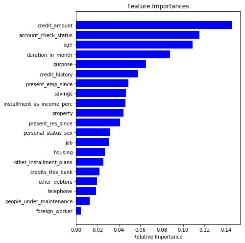

```python
# random forest classifier
rfc = RandomForestClassifier(n_estimators=200, max_depth=12, random_state=42)
rfc.fit(X_train, y_train)
rfc_val = rfc.predict_proba(X_val)[:,1]

features = X_train.columns
importances = rfc.feature_importances_
indices = np.argsort(importances)

# This plot shows the average decrease in impurity/ information gain over all trees in the forest
plt.figure(figsize=(6,8))
plt.title('Feature Importances')
plt.barh(range(len(indices)), importances[indices], color='b', align='center')
plt.yticks(range(len(indices)), [features[i] for i in indices])
plt.xlabel('Relative Importance')
```

```
The ROC AUC for Random Forest is 0.7923608289313288 vs the baseline AUC of 0.5
The best threshold is 0.65
              precision    recall  f1-score   support

           0       0.55      0.65      0.59        46
           1       0.84      0.77      0.80       107

    accuracy                           0.73       153
   macro avg       0.69      0.71      0.70       153
weighted avg       0.75      0.73      0.74       153

The cost of misclassification on the validation set is 105
```

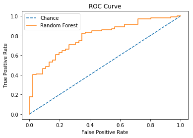

```python
rfc_thresh = evaluate_model(y_val, rfc_val, 'Random Forest', test_name='validation')
```

How do we interpret this graph?

The ROC Curve plots the False Positive Rate (FPR) on the x-axis and the True Positive Rate (TPR) on the y-axis. FPR is the proportion of those cases that we have classified as positive when they are in fact negative. TPR is the proportion of those cases that we have classified as positive when they are in fact positive. The top right corner of the curve has a TPR and FPR of 1 because we have classified everything as positive. Ideally we would want TPR to be as high as possible and FPR to be as low as possible. In this setup, our Area Under Curve (AUC) would be very high. The AUC can also be interpreted as the number of positive cases that are ranked higher (predicted to have a value higher) than the number of negative cases. If our model didn't differentiate between the positive and negative class well, that is, if it randomly chose one to be higher than the other, then the AUC would be 0.5. This would be a chance classifier. The Random Forest model has an AUC of a little over 0.79 which means that the probability that an actual positive case will be predicted to have a value higher than an actual negative case is 0.79

Precision is the proportion of cases that are correctly classified as positive out of those cases that are predicted as positive. Recall is the same as TPR. Ideally our precision and recall should both be as high as possible. In this setup, our F1 score which is the harmonic mean of precision and recall, would also be very high (has a ceiling of 1). With the best threshold we have an F1-score of 0.8 on the positive class. These scores are lesser for the negative or defaulters class. The threshold is set to a 0.65 which means that only those customers that have a high probability of being credit worthy are predicted as credit worthy.

#### LightGBM

```
Training until validation scores don't improve for 10 rounds.
[10]	train's auc: 0.834081	valid's auc: 0.731308
[20]	train's auc: 0.840117	valid's auc: 0.72755
Early stopping, best iteration is:
[17]	train's auc: 0.840864	valid's auc: 0.73913
```

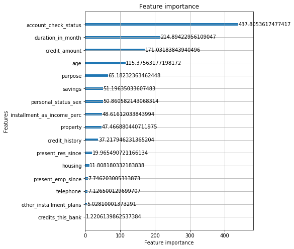

```python
# lightgbm classifier
lgb_params = {
               'feature_fraction': 0.75, # Proportion of features to be selected for each tree
               'metric': 'auc',
               'nthread': 1,
               'min_data_in_leaf': 2**5, # Minimum data in one leaf
               'bagging_fraction': 0.75, # Proportion of observations to use when building a tree
               'learning_rate': 0.01, # Weightage given to every tree
               'objective': 'binary',
               'bagging_seed': 2**7,
               'num_leaves': 40, # LightGBM builds asymmetric trees. Thus even trees with less leaves can be very deep
               'bagging_freq':1, # Performs bagging at every iteration
               'verbose':0
              }
lgb_train = lgb.Dataset(X_train, label=y_train)
lgb_valid = lgb.Dataset(X_val, label=y_val)
# This model stops training if the validation scores don't improve successively for 10 iterations/ tree that is built
lgbc = lgb.train(lgb_params, lgb_train, valid_sets=[lgb_train, lgb_valid],
                 valid_names=['train','valid'], verbose_eval=10, num_boost_round=100, early_stopping_rounds=10)
lgbc_val = lgbc.predict(X_val)
# This plot shows the total gains (information gain) of splits which use this feature
lgb.plot_importance(lgbc, figsize=(6,8), importance_type='gain')
```

```
The ROC AUC for LightGBM is 0.7391304347826085 vs the baseline AUC of 0.5
The best threshold is 0.55
              precision    recall  f1-score   support

           0       0.35      0.89      0.50        46
           1       0.86      0.29      0.43       107

    accuracy                           0.47       153
   macro avg       0.61      0.59      0.47       153
weighted avg       0.71      0.47      0.45       153

The cost of misclassification on the validation set is 101
```

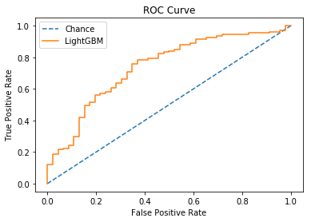

```python
lgbc_thresh = evaluate_model(y_val, lgbc_val, 'LightGBM', test_name='validation')
```

The ROC AUC for LightGBM is lesser than Random Forest. However, the cost of misclassification on the validation set is also lesser. The recall for the negative class is much higher than the positive class and as a result we have more false negatives than positives.

#### Logistic Regression

```python
# Dummifying the categorical attributes and scaling the continous ones
def dummify_and_scale(X, categ_cols, cont_cols, scaler=None):
    list_dummy = []
    for col in categ_cols:
        X_out = pd.get_dummies(pd.Categorical(X[col], categories=df_preprocessed[col].unique()),
                               drop_first=True)
        X_out.columns = [col + '_' + str(dummy) for dummy in X_out.columns] # appending level to the dummy column name
        list_dummy.append(X_out)
    X_out = pd.concat(list_dummy, axis=1)
    X_out.index = X.index

    if scaler == None:
        scaler = StandardScaler()
        scaler.fit(X[cont_cols])
    X_scaled = pd.DataFrame(scaler.transform(X[cont_cols]), columns=cont_cols, index=X.index)

    X_out = pd.concat([X_out, X_scaled], axis=1)
    return(X_out, scaler)

X_train_dummy, scaler = dummify_and_scale(X_train, categ_cols, cont_cols)
X_val_dummy, _ = dummify_and_scale(X_val, categ_cols, cont_cols, scaler)
X_test_dummy, _ = dummify_and_scale(X_test, categ_cols, cont_cols, scaler)
```

```
Optimization terminated successfully.
         Current function value: 0.464947
         Iterations 7
                              Results: Logit
==========================================================================
Model:                 Logit               Pseudo R-squared:    0.237
Dependent Variable:    credit_worthy       AIC:                 744.1363
Date:                  2020-02-19 15:24    BIC:                 962.3820
No. Observations:      697                 Log-Likelihood:      -324.07
Df Model:              47                  LL-Null:             -424.84
Df Residuals:          649                 LLR p-value:         4.9053e-21
Converged:             1.0000              Scale:               1.0000
No. Iterations:        7.0000
--------------------------------------------------------------------------
                            Coef.  Std.Err.    z    P>|z|   [0.025  0.975]
--------------------------------------------------------------------------
account_check_status_0      0.7663   0.2479  3.0915 0.0020  0.2805  1.2522
account_check_status_3      2.2640   0.2633  8.5983 0.0000  1.7479  2.7800
account_check_status_2      1.2071   0.4297  2.8094 0.0050  0.3650  2.0492
credit_history_3           -0.3057   0.2673 -1.1440 0.2526 -0.8296  0.2181
credit_history_2           -0.1602   0.3867 -0.4143 0.6786 -0.9183  0.5978
credit_history_4           -1.5080   0.5489 -2.7475 0.0060 -2.5837 -0.4322
credit_history_0           -0.7295   0.5653 -1.2904 0.1969 -1.8374  0.3785
purpose_0                  -0.6633   0.4994 -1.3283 0.1841 -1.6421  0.3154
purpose_7                   0.3219   0.3108  1.0357 0.3003 -0.2873  0.9311
purpose_2                  -0.5201   0.2729 -1.9060 0.0567 -1.0549  0.0147
purpose_3                   0.8235   0.4267  1.9300 0.0536 -0.0128  1.6597
purpose_1                   0.2905   0.3864  0.7518 0.4522 -0.4669  1.0479
purpose_8                  -0.1697   0.8756 -0.1939 0.8463 -1.8859  1.5464
purpose_5                  -0.7440   0.6699 -1.1106 0.2668 -2.0569  0.5690
purpose_6                   0.5218   0.7805  0.6685 0.5038 -1.0079  2.0515
purpose_9                   1.2693   1.2296  1.0323 0.3019 -1.1407  3.6792
savings_1                  -0.3140   0.2579 -1.2174 0.2235 -0.8194  0.1915
savings_3                  -0.3058   0.4548 -0.6723 0.5014 -1.1972  0.5857
savings_0                   0.7277   0.6235  1.1671 0.2432 -0.4944  1.9498
savings_2                  -0.2953   0.3779 -0.7812 0.4347 -1.0360  0.4455
present_emp_since_2         0.3884   0.2823  1.3758 0.1689 -0.1649  0.9418
present_emp_since_3         0.8118   0.3280  2.4746 0.0133  0.1688  1.4547
present_emp_since_4         0.5569   0.5050  1.1029 0.2701 -0.4328  1.5466
present_emp_since_1         0.0419   0.3461  0.1210 0.9037 -0.6365  0.7202
```

[output cut: 10 more lines]

```
housing_0                  -0.0606   0.5314 -0.1140 0.9092 -1.1021  0.9810
housing_2                  -0.2261   0.2895 -0.7809 0.4348 -0.7936  0.3414
job_3                      -0.0674   0.2881 -0.2338 0.8151 -0.6321  0.4973
job_0                       0.3995   0.3187  1.2536 0.2100 -0.2251  1.0241
job_2                       0.5957   0.7528  0.7914 0.4287 -0.8797  2.0711
telephone_0                 0.2000   0.2239  0.8930 0.3718 -0.2389  0.6389
foreign_worker_0            1.6330   0.7336  2.2261 0.0260  0.1952  3.0708
present_res_since          -0.1023   0.1159 -0.8832 0.3771 -0.3294  0.1247
credits_this_bank          -0.0477   0.1234 -0.3864 0.6992 -0.2894  0.1941
people_under_maintenance   -0.0106   0.1083 -0.0981 0.9219 -0.2228  0.2016
duration_in_month          -0.1969   0.1302 -1.5119 0.1305 -0.4520  0.0583
age                         0.3777   0.1263  2.9892 0.0028  0.1300  0.6253
installment_as_income_perc -0.3741   0.1160 -3.2257 0.0013 -0.6014 -0.1468
credit_amount              -0.3972   0.1437 -2.7636 0.0057 -0.6789 -0.1155
==========================================================================
```

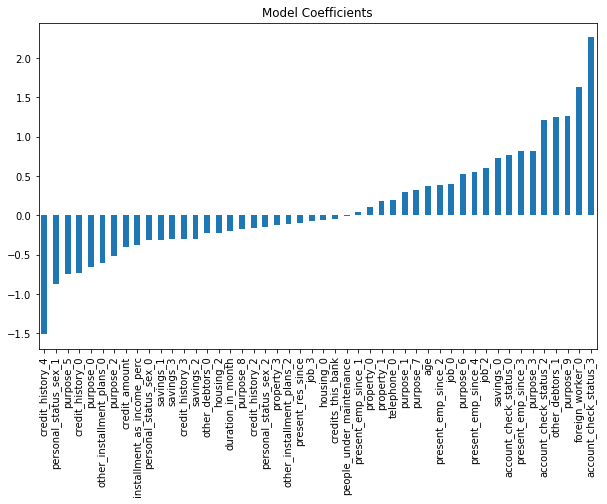

```python
# logistic regression
logit_model = sm.Logit(y_train, X_train_dummy)
lrc = logit_model.fit()
lrc_val = lrc.predict(X_val_dummy).values
print(lrc.summary2())

plt.figure(figsize=(10,6))
coef = lrc.params.sort_values()
coef.plot(kind='bar', title='Model Coefficients')
```

```
The ROC AUC for Logistic Regression is 0.758025193010971 vs the baseline AUC of 0.5
The best threshold is 0.75
              precision    recall  f1-score   support

           0       0.49      0.78      0.61        46
           1       0.88      0.65      0.75       107

    accuracy                           0.69       153
   macro avg       0.68      0.72      0.68       153
weighted avg       0.76      0.69      0.71       153

The cost of misclassification on the validation set is 87
```

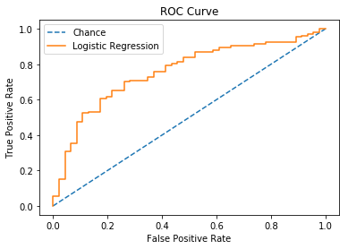

```python
lrc_thresh = evaluate_model(y_val, lrc_val, 'Logistic Regression', test_name='validation')
```

This model has the least cost of all 3

- For the negative class: LightGBM Recall > Logistic Regression Recall > Random Forest Recall
- For the positive class: Random Forest Recall > Logistic Regression Recall > LightGBM Recall

Thus the model is well balanced and has an ROC AUC that is less than Random Forests but more than LightGBM. Since cost is a more important factor than ROC AUC, we will choose this model as the best model. The significant attributes are listed below. These attributes have been chosen on the basis of p-value. P-values are calculated on the basis of the value of coefficients and their standard errors. The null hypothesis is that the independent and dependent variables have no relationship. If the standard error for the coefficients contained a 0 than it would mean that the variable has no relationship with the target and the p-value would be high. In our case, only a select number of attributes have a p-value less than a significance level of 0.05

```python
significant_attributes  = lrc.pvalues.index[np.argsort(lrc.pvalues.values)]
print('Odds')
for attr in significant_attributes[:5]:
    print(attr, np.exp(lrc.params.loc[attr]))
print('\nProbabilities')
for attr in significant_attributes[:5]:
    print(attr, np.exp(lrc.params.loc[attr])/(1+np.exp(lrc.params.loc[attr])))
```

```
Odds
account_check_status_3 9.621203138179249
installment_as_income_perc 0.6878898258867359
account_check_status_0 2.151839041169089
age 1.4588544032037158
account_check_status_2 3.343724301697137

Probabilities
account_check_status_3 0.9058487078167845
installment_as_income_perc 0.4075442693810609
account_check_status_0 0.6827249149026731
age 0.5933065419826934
account_check_status_2 0.7697828106610519
```

```python
for val in dict_le['account_check_status'].classes_:
    print('Value:{} \t Label:{}'.format(val, dict_le['account_check_status'].transform([val])))
```

```
Value:0 <= ... < 200 DM 	 Label:[0]
Value:< 0 DM 	 Label:[1]
Value:>= 200 DM / salary assignments for at least 1 year 	 Label:[2]
Value:no checking account 	 Label:[3]
```

## Predicting On Test Set

Now that we have trained a model and determined the best thresholds for making predictions, we need to see if our beliefs are generalizable. Thus we'll retrain our model on the train and validation set and then make a prediction on the test set.

```python
X_train = pd.concat([X_train, X_val], axis=0)
X_train_dummy = pd.concat([X_train_dummy, X_val_dummy], axis=0)
y_train = pd.concat([y_train, y_val], axis=0)

# Fitting Random Forest
rfc.fit(X_train, y_train)
rfc_test = rfc.predict_proba(X_test)[:,1]

# Fitting LightGBM
lgb_train = lgb.Dataset(X_train, label=y_train)
lgbc = lgb.train(lgb_params, lgb_train, num_boost_round=17)
lgbc_test = lgbc.predict(X_test)

# Fitting Logistic Regression
logit_model = sm.Logit(y_train, X_train_dummy)
lrc = logit_model.fit()
lrc_test = lrc.predict(X_test_dummy).values
```

```
Optimization terminated successfully.
         Current function value: 0.469731
         Iterations 7
```

```
The ROC AUC for Random Forest is 0.8300585284280937 vs the baseline AUC of 0.5
              precision    recall  f1-score   support

           0       0.59      0.72      0.65        46
           1       0.86      0.78      0.82       104

    accuracy                           0.76       150
   macro avg       0.73      0.75      0.73       150
weighted avg       0.78      0.76      0.77       150

The cost of misclassification on the test set is 88
```

```
0.65
```

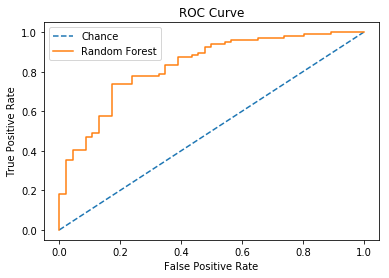

```python
evaluate_model(y_test, rfc_test, 'Random Forest', best_thresh=rfc_thresh, test_name='test')
```

```
The ROC AUC for LightGBM is 0.8166806020066889 vs the baseline AUC of 0.5
              precision    recall  f1-score   support

           0       0.39      0.96      0.55        46
           1       0.94      0.33      0.49       104

    accuracy                           0.52       150
   macro avg       0.67      0.64      0.52       150
weighted avg       0.77      0.52      0.51       150

The cost of misclassification on the test set is 80
```

```
0.55
```

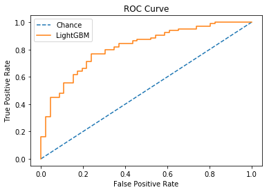

```python
evaluate_model(y_test, lgbc_test, 'LightGBM', best_thresh=lgbc_thresh, test_name='test')
```

```
The ROC AUC for Logistic Regression is 0.8417642140468228 vs the baseline AUC of 0.5
              precision    recall  f1-score   support

           0       0.49      0.83      0.61        46
           1       0.89      0.62      0.73       104

    accuracy                           0.68       150
   macro avg       0.69      0.72      0.67       150
weighted avg       0.77      0.68      0.69       150

The cost of misclassification on the test set is 80
```

```
0.75
```

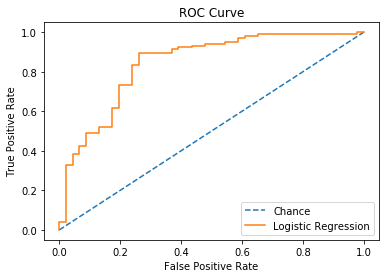

```python
evaluate_model(y_test, lrc_test, 'Logistic Regression', best_thresh=lrc_thresh, test_name='test')
```

The Logistic Regression model has the lowest cost along with the LightGBM model. This is consistent with what we observed during the validation phase. Also, the AUC for Logistic Regression on the test set is the highest out of all models

In order to provide a description of the “best” credit-worthy person based on the selected model, we'll look at the top and bottom deciles of the predicted scores on the test set for Logistic Regression. We'll cycle through the 5 most significant attributes (not dummified) and for every attribute, calculate the most common level for the subset of the customers that are in the bottom and top deciles. For continuous attributes, we'll print the mean. This will give us some idea as to how different these two sets of customers are

```python
def decile_analysis(pred):
    pred_deciles = pd.qcut(pred, 10, labels=np.arange(0,10))
    dict_deciles = {0:'Bottom Decile', 9:'Top Decile'}
    attributes_checked = []
    counter = 0
    for attr in significant_attributes:
        if attr[:-2] in categ_cols: # dummified columns
            attr = attr[:-2]
        if attr in attributes_checked: # to skip dummy attributes
            continue
        for decile, descr in dict_deciles.items():
            print(descr)
            if attr in categ_cols:
                attr_values = X_test[pred_deciles==decile][attr].value_counts(normalize=True)
                print('Attribute: {}, Most common level: {}, Likelihood: {}'.format(attr,
                                                                            dict_le[attr].inverse_transform(attr_values.index)[0],
                                                                            attr_values.iloc[0]))
            else:
                attr_values = X_test[pred_deciles==decile][attr]
                print('Attribute: {}, Mean: {}'.format(attr,
                                                       np.mean(attr_values)))
        attributes_checked.append(attr)
        print('\n')
        counter += 1

        if counter == 5:
            break
```

```python
decile_analysis(lrc_test)
```

```
Bottom Decile
Attribute: account_check_status, Most common level: < 0 DM, Likelihood: 0.7333333333333333
Top Decile
Attribute: account_check_status, Most common level: no checking account, Likelihood: 0.8


Bottom Decile
Attribute: installment_as_income_perc, Mean: 3.466666666666667
Top Decile
Attribute: installment_as_income_perc, Mean: 2.2666666666666666


Bottom Decile
Attribute: age, Mean: 32.13333333333333
Top Decile
Attribute: age, Mean: 38.93333333333333


Bottom Decile
Attribute: credit_amount, Mean: 5274.2
Top Decile
Attribute: credit_amount, Mean: 3202.733333333333


Bottom Decile
Attribute: credit_history, Most common level: existing credits paid back duly till now, Likelihood: 0.4666666666666667
Top Decile
Attribute: credit_history, Most common level: critical account/ other credits existing (not at this bank), Likelihood: 0.5333333333333333
```

The most credit worthy customers have no checking account, are usually older, have a lower installment to pay (as expressed as a percentage of their disposable income) and a lower credit amount. Surprisingly these customers may also turn out to be customers that have critical credit history.